# Relatório de dados de Sífilis

Autor

Mikael Marin Coletto

# Sífilis congênita

## Introdução

Este relatório tem como objetivo descrever o banco de dados de dados longitudinal sobre a Sífilis Gestacional e Congênita no Brasil no período de 2007 a 2023, obtidos do Sistema de Informação de Agravos de Notificação (SINAN). Os dados foram agregados segundo período, município, faixa etária, raça/cor e escolaridade e integram variáveis de origem de outras fontes e sistemas de informações como Sistema de Informações de Nascidos Vivos (SINASC), Cadastro Nacional de Estabelecimentos de Saúde (CNES), Sistema de Informações Hospitalares (SIH), Sistema de Informação de Mortalidade (SIM), Programa Bolsa Família, Cobertura de Estratégia de Saúde da Família e Atenção Primária, indicadores socioeconômicos, entre outros.

## Dados

- Município de residência
- Ano do diagnóstico
- Mês do diagnóstico
- Faixa etária
- Raça/cor
- Escolaridade
- Número de casos de Sífilis

**Mostrar o código**

```r
sif_13m <- T
if(sif_13m){
  df_sifilis <- readRDS("data-raw/df_sifilis_all.RDS") |>
  janitor::clean_names() |>
  dplyr::rename(nasc_c_anom = nascidos_com_anomalia,
                nasc_viv = nascidos_vivos,
                raca = cs_raca,
                escolaridade = escolaridade,
                uf_res = uf_resi,
                mun_res = id_mn_resi)
} else {
  df_sifilis <- readRDS("data-raw/df_sifilis_mun_ano_fx_et_racacor_esc.RDS")
}
head(df_sifilis) |>
  gt::gt()
```

| id_regiao_resi | nome_regiao_resi | uf_res | nome_uf_resi | sigla_uf_resi | id_macsaude_resi | nome_macsaude_resi | id_regsaud_resi | nome_regsaud_resi | mun_res | nome_mn_resi | ano | mes | fx_etaria | raca | escolaridade | casos_sifg | hosp_sifg | nasc_viv | nascidos_peso1 | nascidos_peso2 | nascidos_peso3 | nascidos_peso4 | nascidos_peso5 | nascidos_peso6 | nascidos_peso7 | nasc_c_anom | anomal_001 | anomal_002 | anomal_003 | … |
| --- | --- | --- | --- | --- | --- | --- | --- | --- | --- | --- | --- | --- | --- | --- | --- | --- | --- | --- | --- | --- | --- | --- | --- | --- | --- | --- | --- | --- | --- | --- |
| 3 | Região Sudeste | 35 | São Paulo | SP | 3534 | RRAS1 | 35015 | Grande ABC | 354330 | Ribeirão Pires | 2017 | 03 | 30-39 | Parda | Ensino médio incompleto | 0 | 0 | 3 | 0 | 0 | 0 | 2 | 1 | 0 | 0 | 0 | 0 | 0 | 0 | … |
| 3 | Região Sudeste | 31 | Minas Gerais | MG | 3112 | TRIANGULO DO SUL | 31070 | Araxá | 312950 | Ibiá | 2013 | 04 | 30-39 | Parda | Educação superior completa | 0 | 0 | 2 | 0 | 0 | 0 | 0 | 2 | 0 | 0 | 0 | 0 | 0 | 0 | … |
| 5 | Região Centro-Oeste | 51 | Mato Grosso | MT | 5104 | MACRORREGIAO LESTE | 51006 | Médio Araguaia | 510020 | Água Boa | 2020 | 03 | 20-24 | Parda | Ensino médio completo | 0 | 0 | 3 | 0 | 0 | 0 | 1 | 2 | 0 | 0 | 0 | 0 | 0 | 0 | … |
| 1 | Região Norte | 13 | Amazonas | AM | 1303 | LESTE | 13005 | Baixo Amazonas | 130050 | Barreirinha | 2014 | 03 | 30-39 | Parda | 1ª a 4ª série incompleta do EF | 0 | 0 | 2 | 0 | 0 | 0 | 1 | 1 | 0 | 0 | 0 | 0 | 0 | 0 | … |
| 2 | Região Nordeste | 23 | Ceará | CE | 2307 | 4ª MACRO - SERTAO CENTRAL | 23014 | 14ª Região Tauá | 231330 | Tauá | 2018 | 05 | 20-24 | Branca | Educação superior incompleta | 0 | 0 | 2 | 0 | 0 | 0 | 1 | 0 | 1 | 0 | 0 | 0 | 0 | 0 | … |
| 5 | Região Centro-Oeste | 50 | Mato Grosso do Sul | MS | 5005 | TRES LAGOAS | 50004 | Três Lagoas | 500290 | Cassilândia | 2021 | 03 | 40-59 | Branca | Educação superior completa | 0 | 0 | 1 | 0 | 0 | 0 | 1 | 0 | 0 | 0 | 0 | 0 | 0 | 0 | … |

## Análise Exploratória

### Completude de variáveis (Geral)

**Mostrar o código**

```r
variaveis <- colnames(df_sifilis)

library(dplyr)

## Definindo como NA as variáveis que possuem valores inválidos
df_sifilis_test <- df_sifilis %>%
  dplyr::mutate(across(where(is.character), ~ ifelse(.x %in% c("****", "Em branco/Inválido"), NA, .x)))

df_completude <- data.frame(variavel = character(), completude = numeric())
for(i in variaveis){
  completude = round(100*(sum(!is.na(df_sifilis_test[[i]]))/nrow(df_sifilis_test)), 5)
  df_completude <- rbind(df_completude, data.frame(variavel = i, completude = completude))
}

df_completude |>
  gt::gt() |>
  gt::cols_label(variavel = "Variável", completude = "Completude")
```

| Variável | Completude |
| --- | --- |
| id_regiao_resi | 99.98785 |
| nome_regiao_resi | 99.98785 |
| uf_res | 100.00000 |
| nome_uf_resi | 99.98785 |
| sigla_uf_resi | 99.98785 |
| id_macsaude_resi | 99.98785 |
| nome_macsaude_resi | 99.98785 |
| id_regsaud_resi | 99.98785 |
| nome_regsaud_resi | 99.98785 |
| mun_res | 100.00000 |
| nome_mn_resi | 99.98785 |
| ano | 99.99968 |
| mes | 100.00000 |
| fx_etaria | 99.99625 |
| raca | 86.24619 |
| escolaridade | 85.44501 |
| casos_sifg | 100.00000 |
| hosp_sifg | 100.00000 |
| nasc_viv | 100.00000 |
| nascidos_peso1 | 100.00000 |
| nascidos_peso2 | 100.00000 |
| nascidos_peso3 | 100.00000 |
| nascidos_peso4 | 100.00000 |
| nascidos_peso5 | 100.00000 |
| nascidos_peso6 | 100.00000 |
| nascidos_peso7 | 100.00000 |
| nasc_c_anom | 100.00000 |
| anomal_001 | 100.00000 |
| anomal_002 | 100.00000 |
| anomal_003 | 100.00000 |
| anomal_004 | 100.00000 |
| anomal_005 | 100.00000 |
| anomal_006 | 100.00000 |
| anomal_007 | 100.00000 |
| anomal_008 | 100.00000 |
| anomal_009 | 100.00000 |
| anomal_010 | 100.00000 |
| anomal_011 | 100.00000 |
| anomal_012 | 100.00000 |
| anomal_013 | 100.00000 |
| anomal_014 | 100.00000 |
| anomal_015 | 100.00000 |
| anomal_016 | 100.00000 |
| n_posto_saude | 99.98210 |
| n_ubs | 99.98210 |
| qtd_familias_pbf | 100.00000 |
| ibp_zscore | 99.95008 |
| ibp_quintil | 99.95008 |
| ibp_decil | 99.95008 |
| idhm_2010 | 99.95008 |
| idhm_renda_2010 | 99.95008 |
| idhm_longevidade_2010 | 99.95008 |
| idhm_educacao_2010 | 99.95008 |
| pib_milhao_2010 | 99.95008 |
| pibpercapita_mil_2010 | 99.95008 |
| renda_gini_2010 | 99.55376 |
| analfa_total_2010 | 99.55376 |
| analfa_mulher_2010 | 99.55376 |
| esc_anos_2010 | 99.95008 |
| desemprego_2010 | 99.90605 |
| pobres_2010 | 99.94440 |
| extr_pobres_2010 | 99.49675 |
| pct_domicilios_banheiro_agua_encanada_2010 | 99.95008 |
| pct_domicilios_coleta_lixo_2010 | 99.90135 |
| pct_domicilios_energia_eletrica_2010 | 99.95008 |
| pct_domicilios_com_densidade_maior_que_2_2010 | 99.95008 |

### Completude de variáveis (por ano)

**Mostrar o código**

```r
vars <- c("fx_etaria", "raca", "escolaridade")

## Período
years <- 2007:2023

## Criando dataframe
df_var <- data.frame(var = character())

## Adicionando colunas de anos
for (year in years) {
  df_var[, paste0(year)] <- rep(NA, nrow(df_var))  # Add a column named "Yyyy" with NA values
}

for(var in vars){
  # var <- "fx_etaria"
  df_sifilis_ano_var <- df_sifilis_test |>
    dplyr::select(ano, !!as.name(var), casos_sifg) |>
    dplyr::filter(!is.na(ano)) |>
    dplyr::group_by(ano, !!as.name(var)) |>
    dplyr::mutate(n = sum(casos_sifg)) |>
    dplyr::arrange(ano, !!as.name(var)) |>
    dplyr::select(-casos_sifg) |>
    dplyr::distinct(ano, !!as.name(var), .keep_all = TRUE)

  df_sifilis_ano_var <- df_sifilis_ano_var |>
    dplyr::mutate(categs_var = ifelse(is.na(!!as.name(var)), "inv", "val")) |>
    dplyr::group_by(ano, categs_var) |>
    dplyr::summarise(n = sum(n)) |>
    dplyr::ungroup() |>
    tidyr::pivot_wider(names_from = categs_var, values_from = n)

  df_sifilis_ano_var <- df_sifilis_ano_var |>
    dplyr::mutate(perc = paste0(round(val/(val + inv)*100, 2), "%")) |>
    dplyr::select(ano, perc)


  df_var_aux <- t(df_sifilis_ano_var) |>
    tibble::as_tibble(.name_repair = "minimal") |>
    janitor::row_to_names(row_number = 1) |>
    dplyr::mutate(var = var) |>
    dplyr::select(var, everything())

  df_var <- rbind(df_var, df_var_aux)
}

df_var |>
  gt::gt() |>
  gt::cols_label(var = "Variável")
```

| Variável | 2007 | 2008 | 2009 | 2010 | 2011 | 2012 | 2013 | 2014 | 2015 | 2016 | 2017 | 2018 | 2019 | 2020 | 2021 | 2022 | 2023 |
| --- | --- | --- | --- | --- | --- | --- | --- | --- | --- | --- | --- | --- | --- | --- | --- | --- | --- |
| fx_etaria | 99.94% | 100% | 99.96% | 99.97% | 100% | 99.98% | 99.98% | 99.97% | 100% | 99.95% | 99.92% | 99.98% | 99.98% | 99.97% | 99.98% | 99.99% | 99.99% |
| raca | 88.53% | 89.5% | 91.23% | 90.49% | 89.62% | 89.85% | 89.71% | 90.78% | 91.19% | 91.89% | 93.4% | 93.05% | 93.01% | 93.7% | 93.77% | 93.78% | 95.13% |
| escolaridade | 72.2% | 69.7% | 72.04% | 70.37% | 68.98% | 69.48% | 69.2% | 70.37% | 71.11% | 72.04% | 74.02% | 73.39% | 73.11% | 73.49% | 72.79% | 73.05% | 73.79% |

### Variáveis numéricas

**Mostrar o código**

```r
df_sifilis_numeric_vars <- df_sifilis_test |>
  dplyr::select(where(is.numeric))

df_numeric <- data.frame(variavel = character(),
                         min = numeric(), median = numeric(), media = numeric() , max = numeric(),
                         total = numeric())

variaveis <- colnames(df_sifilis_numeric_vars)
for(i in variaveis){
  min = min(df_sifilis_numeric_vars[[i]], na.rm = TRUE)
  median = median(df_sifilis_numeric_vars[[i]], na.rm = TRUE)
  media = round(mean(df_sifilis_numeric_vars[[i]], na.rm = TRUE), 2)
  max = max(df_sifilis_numeric_vars[[i]], na.rm = TRUE)
  sum = sum(df_sifilis_numeric_vars[[i]], na.rm = TRUE)
  df_numeric <- rbind(df_numeric, data.frame(variavel = i,
                                             min = min, median = median, media = media,
                                             max = max, total = sum))
}

df_numeric |>
  gt::gt() |>
  gt::cols_label(variavel = "Variável", min = "Mínimo", median = "Mediana", media = "Média", max = "Máximo", total = "Total")
```

| Variável | Mínimo | Mediana | Média | Máximo | Total |
| --- | --- | --- | --- | --- | --- |
| id_regiao_resi | 1.000000 | 3.0000000 | 2.78 | 5.000000e+00 | 36323558 |
| id_macsaude_resi | 1101.000000 | 3105.0000000 | 3150.66 | 5.302000e+03 | 41200988151 |
| id_regsaud_resi | 11001.000000 | 31037.0000000 | 31426.35 | 5.300100e+04 | 410960000425 |
| casos_sifg | 0.000000 | 0.0000000 | 0.05 | 7.200000e+01 | 618921 |
| hosp_sifg | 0.000000 | 0.0000000 | 0.02 | 3.800000e+01 | 197645 |
| nasc_viv | 0.000000 | 1.0000000 | 3.69 | 5.730000e+03 | 48257686 |
| nascidos_peso1 | 0.000000 | 0.0000000 | 0.02 | 5.200000e+01 | 293403 |
| nascidos_peso2 | 0.000000 | 0.0000000 | 0.03 | 7.000000e+01 | 362213 |
| nascidos_peso3 | 0.000000 | 0.0000000 | 0.27 | 4.740000e+02 | 3485588 |
| nascidos_peso4 | 0.000000 | 0.0000000 | 0.85 | 1.454000e+03 | 11078630 |
| nascidos_peso5 | 0.000000 | 1.0000000 | 2.34 | 3.596000e+03 | 30561506 |
| nascidos_peso6 | 0.000000 | 0.0000000 | 0.19 | 2.770000e+02 | 2425855 |
| nascidos_peso7 | 0.000000 | 0.0000000 | 0.00 | 1.190000e+02 | 50491 |
| nasc_c_anom | 0.000000 | 0.0000000 | 0.03 | 9.000000e+01 | 392640 |
| anomal_001 | 0.000000 | 0.0000000 | 0.00 | 5.000000e+00 | 11286 |
| anomal_002 | 0.000000 | 0.0000000 | 0.00 | 1.000000e+01 | 36601 |
| anomal_003 | 0.000000 | 0.0000000 | 0.00 | 3.200000e+01 | 40185 |
| anomal_004 | 0.000000 | 0.0000000 | 0.00 | 7.000000e+00 | 29033 |
| anomal_005 | 0.000000 | 0.0000000 | 0.00 | 4.000000e+00 | 1099 |
| anomal_006 | 0.000000 | 0.0000000 | 0.00 | 2.800000e+01 | 24683 |
| anomal_007 | 0.000000 | 0.0000000 | 0.00 | 6.000000e+00 | 7513 |
| anomal_008 | 0.000000 | 0.0000000 | 0.00 | 1.500000e+01 | 37574 |
| anomal_009 | 0.000000 | 0.0000000 | 0.00 | 7.000000e+00 | 2693 |
| anomal_010 | 0.000000 | 0.0000000 | 0.00 | 1.600000e+01 | 53724 |
| anomal_011 | 0.000000 | 0.0000000 | 0.01 | 2.200000e+01 | 124254 |
| anomal_012 | 0.000000 | 0.0000000 | 0.00 | 2.700000e+01 | 58552 |
| anomal_013 | 0.000000 | 0.0000000 | 0.00 | 1.300000e+01 | 23202 |
| anomal_014 | 0.000000 | 0.0000000 | 0.00 | 5.000000e+00 | 1714 |
| anomal_015 | 0.000000 | 0.0000000 | 0.00 | 1.000000e+00 | 2 |
| anomal_016 | 0.000000 | 0.0000000 | 0.00 | 1.000000e+00 | 9 |
| n_posto_saude | 0.000000 | 1.0000000 | 2.63 | 1.100000e+02 | 34386257 |
| n_ubs | 0.000000 | 8.0000000 | 16.43 | 5.720000e+02 | 214841349 |
| qtd_familias_pbf | 0.000000 | 2207.0000000 | 7589.98 | 7.549570e+05 | 99265675149 |
| ibp_zscore | -1.762680 | -0.3959936 | -0.15 | 2.729453e+00 | -1924744 |
| ibp_quintil | 1.000000 | 4.0000000 | 3.80 | 5.000000e+00 | 49708463 |
| ibp_decil | 1.000000 | 8.0000000 | 7.19 | 1.000000e+01 | 93969567 |
| idhm_2010 | 0.418000 | 0.6840000 | 0.67 | 8.620000e-01 | 8800974 |
| idhm_renda_2010 | 0.400000 | 0.6730000 | 0.66 | 8.910000e-01 | 8613320 |
| idhm_longevidade_2010 | 0.672000 | 0.8130000 | 0.81 | 8.940000e-01 | 10537652 |
| idhm_educacao_2010 | 0.207000 | 0.5840000 | 0.58 | 8.250000e-01 | 7559160 |
| pib_milhao_2010 | 7.218000 | 269.0410000 | 4001.73 | 4.504920e+05 | 52310512300 |
| pibpercapita_mil_2010 | 2.261647 | 10.6643553 | 14.85 | 3.118820e+02 | 194146817 |
| renda_gini_2010 | 0.284100 | 0.5204000 | 0.52 | 8.082000e-01 | 6796061 |
| analfa_total_2010 | 0.900000 | 10.8000000 | 14.18 | 4.710000e+01 | 184683443 |
| analfa_mulher_2010 | 0.900000 | 10.9000000 | 13.57 | 4.230000e+01 | 176685298 |
| esc_anos_2010 | 4.340000 | 9.4500000 | 9.39 | 1.283000e+01 | 122716568 |
| desemprego_2010 | 0.060000 | 6.7200000 | 7.16 | 3.915000e+01 | 93504346 |
| pobres_2010 | 0.190000 | 14.9800000 | 22.00 | 7.859000e+01 | 287570262 |
| extr_pobres_2010 | 0.020000 | 5.0300000 | 10.68 | 6.967000e+01 | 138957849 |
| pct_domicilios_banheiro_agua_encanada_2010 | 3.260000 | 91.2600000 | 80.68 | 1.000000e+02 | 1054587913 |
| pct_domicilios_coleta_lixo_2010 | 0.060000 | 97.9500000 | 94.17 | 1.000000e+02 | 1230347144 |
| pct_domicilios_energia_eletrica_2010 | 27.410000 | 99.5200000 | 97.34 | 1.000000e+02 | 1272438836 |
| pct_domicilios_com_densidade_maior_que_2_2010 | 0.650000 | 26.6800000 | 28.29 | 8.864000e+01 | 369811750 |

### Tabela geral

**Mostrar o código**

```r
df_sifilis_categoric_vars <- df_sifilis |>
  dplyr::select(where(is.character))

variaveis <- colnames(df_sifilis_categoric_vars)

df_categoric <- data.frame(variavel = character(),
                           n_distinct = numeric(),
                           levels = character())

for(i in variaveis){
  n_distinct = n_distinct(df_sifilis_categoric_vars[[i]], na.rm = TRUE)
  levels = paste(sort(unique(df_sifilis_categoric_vars[[i]])), collapse = ", ")
  if(length(unique(df_sifilis_categoric_vars[[i]])) > 20){
    levels = "Muitos valores distintos (> 20)"
  }
  df_categoric <- rbind(df_categoric, data.frame(variavel = i,
                                                 n_distinct = n_distinct, levels = levels))
  # print(df_categoric)
}

df_categoric |>
  gt::gt() |>
  gt::cols_label(variavel = "Variável", n_distinct = "Nº de valores distintos", levels = "Valores distintos")
```

| Variável | Nº de valores distintos | Valores distintos |
| --- | --- | --- |
| nome_regiao_resi | 5 | Região Centro-Oeste, Região Nordeste, Região Norte, Região Sudeste, Região Sul |
| uf_res | 27 | Muitos valores distintos (> 20) |
| nome_uf_resi | 27 | Muitos valores distintos (> 20) |
| sigla_uf_resi | 27 | Muitos valores distintos (> 20) |
| nome_macsaude_resi | 100 | Muitos valores distintos (> 20) |
| nome_regsaud_resi | 442 | Muitos valores distintos (> 20) |
| mun_res | 5608 | Muitos valores distintos (> 20) |
| nome_mn_resi | 5297 | Muitos valores distintos (> 20) |
| ano | 18 | ****, 2007, 2008, 2009, 2010, 2011, 2012, 2013, 2014, 2015, 2016, 2017, 2018, 2019, 2020, 2021, 2022, 2023 |
| mes | 13 | **, 01, 02, 03, 04, 05, 06, 07, 08, 09, 10, 11, 12 |
| fx_etaria | 8 | 10-14, 15-19, 20-24, 25-29, 30-39, 40-59, 60+, Em branco/Inválido |
| raca | 6 | Amarela, Branca, Em branco/Inválido, Indigena, Parda, Preta |
| escolaridade | 12 | 1ª a 4ª série incompleta do EF, 4ª série completa do EF, 5ª à 8ª série incompleta do EF, Analfabeto, Educação superior completa, Educação superior incompleta, Em branco/Inválido, Ensino fundamental co… |

**Mostrar o código**

```r
df_categoric_av <- df_categoric |>
  dplyr::filter(n_distinct <= 20)

vars_av <- df_categoric_av$variavel

for(var in vars_av){
  # var <- "ano"
  df_sifilis_categoric_vars |>
    cbind(df_sifilis$casos_sifg) |>
    tibble::as_tibble() |>
    # dplyr::group_by(!!as.name(var)) |>
    dplyr::select(!!as.name(var), casos_sifg = `df_sifilis$casos_sifg`) |>
    ggplot2::ggplot() +
    ggplot2::geom_bar(aes(x = !!as.name(var)), fill = "#ABA2D1") +
    ggplot2::labs(title = paste("Distribuição de", var),
         x = var,
         y = "Número de casos") +
    ggplot2::theme_minimal() +
    ggplot2::theme(axis.text.x = ggplot2::element_text(angle = 45, hjust = 1))
}
```

#### Distribuição de número de casos de Sífilis

##### Ano de diagnóstico

**Mostrar o código**

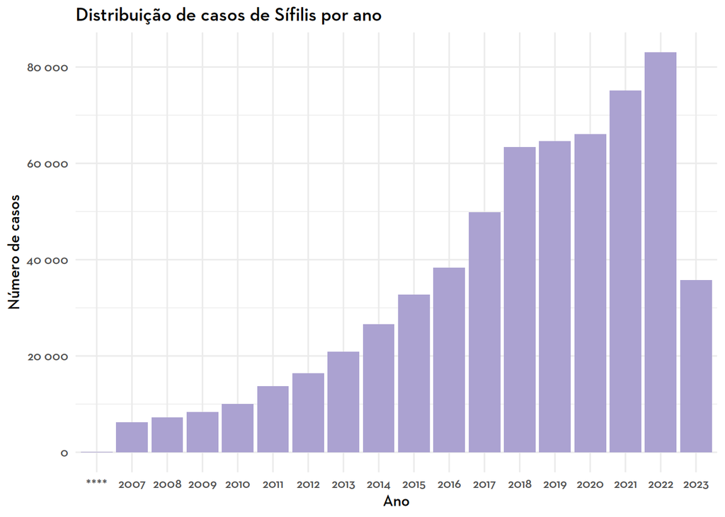

```r
df_sifilis_ano <- df_sifilis |>
  dplyr::group_by(ano) |>
  dplyr::summarise(casos_sifg = sum(casos_sifg)) |>
  dplyr::ungroup()

df_sifilis_ano |>
  ggplot2::ggplot() +
  ggplot2::geom_col(aes(x = ano, y = casos_sifg), fill = "#ABA2D1") +
  ggplot2::labs(title = "Distribuição de casos de Sífilis por ano",
       x = "Ano",
       y = "Número de casos") +
  ggplot2::theme_minimal() +
  ggplot2::scale_y_continuous(labels = scales::number)
```

##### Nos estados

**Mostrar o código**

```r
df_sifilis_uf <- df_sifilis |>
  dplyr::group_by(uf_res) |>
  dplyr::summarise(casos_sifg = sum(casos_sifg),
                   n_nascidos = sum(nasc_viv)) |>
  dplyr::ungroup() |>
  dplyr::mutate(taxa_sifilis = casos_sifg / n_nascidos * 1000)

df_ufs <- data.table::fread("data-raw/ibge-ufs-pop-2022-est.csv") |>
  dplyr::mutate(uf_cod = as.character(uf_cod)) |>
  dplyr::select(uf_cod, uf_nome)

df_sifilis_uf <- dplyr::left_join(df_sifilis_uf, df_ufs, by = c("uf_res" = "uf_cod"))

uf_sf <- sf::read_sf(here::here("data-raw/dados-espaciais/uf_sf.shp")) |>
  dplyr::select(cod_stt, geometry)  |>
  dplyr::mutate(cod_stt = as.character(cod_stt))

df_sifilis_uf_sf <- df_sifilis_uf |>
  dplyr::left_join(uf_sf, by = c("uf_res" = "cod_stt")) |>
  sf::st_as_sf()

df_sifilis_uf_sf <- sf::st_transform(df_sifilis_uf_sf, crs = '+proj=longlat +datum=WGS84')
```

###### Gráfico

**Mostrar o código**

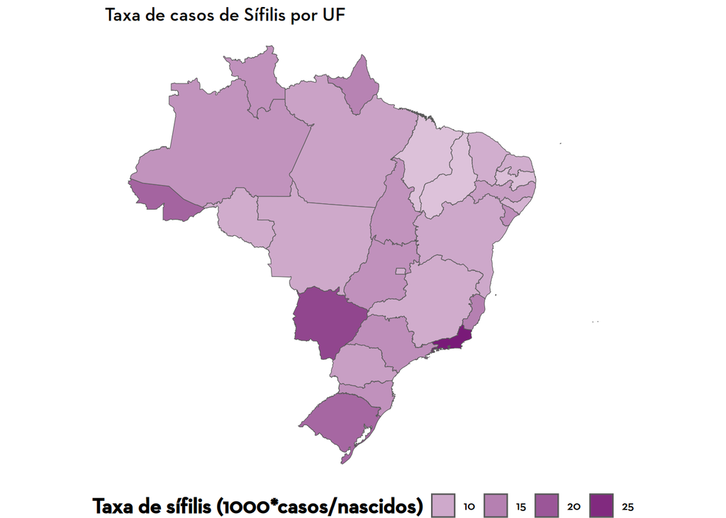

```r
df_sifilis_uf_sf |>
  ggplot2::ggplot() +
  ggplot2::geom_sf(aes(fill = taxa_sifilis)) +
  ggplot2::labs(title = "Taxa de casos de Sífilis por UF",
       fill = "Taxa de sífilis (1000*casos/nascidos)") +
  ggplot2::theme_void() +
  ggplot2::theme(legend.position = "bottom") +
  ggplot2::scale_fill_gradient2(low = "#F2D4F3", high = "#791A78") +
  ggplot2::guides(fill = ggplot2::guide_legend(theme = ggplot2::theme(
    legend.title = ggplot2::element_text(size = 15, face = "bold", colour = "black")
  )))
```

###### Tabela

**Mostrar o código**

```r
df_sifilis_uf |>
  dplyr::select(uf_nome, casos_sifg, n_nascidos, taxa_sifilis) |>
  dplyr::mutate(taxa_sifilis = round(taxa_sifilis, 2)) |>
  gt::gt() |>
  gt::cols_label(uf_nome = "UF", casos_sifg = "Nº de casos", n_nascidos = "Nº de nascidos", taxa_sifilis = "Taxa de sífilis (1000*n_casos/n_nascidos)")
```

| UF | Nº de casos | Nº de nascidos | Taxa de sífilis (1000*n_casos/n_nascidos) |
| --- | --- | --- | --- |
| Rondônia | 4343 | 446826 | 9.72 |
| Acre | 5080 | 277212 | 18.33 |
| Amazonas | 16379 | 1296500 | 12.63 |
| Roraima | 2530 | 196850 | 12.85 |
| Pará | 25787 | 2367885 | 10.89 |
| Amapá | 3703 | 254570 | 14.55 |
| Tocantins | 5279 | 415201 | 12.71 |
| Maranhão | 13967 | 1945302 | 7.18 |
| Piauí | 5715 | 814743 | 7.01 |
| Ceará | 20114 | 2144397 | 9.38 |
| Rio Grande do Norte | 7469 | 781490 | 9.56 |
| Paraíba | 7250 | 973873 | 7.44 |
| Pernambuco | 25772 | 2297827 | 11.22 |
| Alagoas | 7759 | 877218 | 8.85 |
| Sergipe | 7535 | 565928 | 13.31 |
| Bahia | 34935 | 3427248 | 10.19 |
| Minas Gerais | 41703 | 4317864 | 9.66 |
| Espírito Santo | 13545 | 907282 | 14.93 |
| Rio de Janeiro | 95510 | 3608836 | 26.47 |
| São Paulo | 132280 | 9977799 | 13.26 |
| Paraná | 28893 | 2569794 | 11.24 |
| Santa Catarina | 20194 | 1569206 | 12.87 |
| Rio Grande do Sul | 41430 | 2295862 | 18.05 |
| Mato Grosso do Sul | 15640 | 712616 | 21.95 |
| Mato Grosso | 9258 | 920071 | 10.06 |
| Goiás | 20277 | 1576622 | 12.86 |
| Distrito Federal | 6574 | 718664 | 9.15 |

**Mostrar o código**

```r
df_categoric_av <- df_categoric |>
  dplyr::filter(n_distinct <= 20)

vars_av <- df_categoric_av$variavel
i <- vars_av[1]

## Removendo NAs para contagens de categorias
df_sifilis_categoric_vars <- df_sifilis_categoric_vars |>
  dplyr::mutate(across(where(is.character), ~ ifelse(is.na(.x), "NA", .x))) |>
  dplyr::mutate(ano = ifelse(ano == "****", "NA", ano))

df_vars_categ <- data.frame(variavel = character(), categorias = character())
for(i in vars_av){
  categ <- unique(df_sifilis_categoric_vars[[i]])
  cat("\n")
  table <- df_sifilis_categoric_vars[[i]] |>
    dplyr::as_tibble() |>
    dplyr::group_by(value) |>
    dplyr::summarise(n = n()) |>
    dplyr::ungroup() |>
    dplyr::rename(categoria = value)

  total <- sum(table$n)

  table <- table |>
    dplyr::mutate(perc = round(n/total*100, 0)) |>
    dplyr::mutate(row = paste0("**", categoria, ":** ", "</b>", n, " (", perc, "%)")) |>
    dplyr::select(row)

  row <- paste0(table$row, collapse = "; \n")
  # table |> gt::gt()
    # gt::cols_label(categoria = "Categoria", n = "Nº de casos")

  df_vars_categ <- rbind(df_vars_categ, data.frame(variavel = i, categorias = row))

  # table_print <- gt::gt(table, rowname_col = "row", groupname_col = "group")
  # print(table_print)
  # cat("\n")
}
```

**Mostrar o código**

```r
df_vars_categ |>
  gt::gt() |>
  gt::cols_label(variavel = "Variável", categorias = "Categorias: N na categoria (% na categoria)") |>
  gt::fmt_markdown(columns = everything(), rows = everything(), md_engine = "markdown")
```

| Variável | Categorias: N na categoria (% na categoria) |
| --- | --- |
| nome_regiao_resi | **NA:** 1589 (0%); **Região Centro-Oeste:** 1079052 (8%); **Região Nordeste:** 4488903 (34%); **Região Norte:** 1336660 (10%); **Região Sudeste:** 4075400 (31%); **Região Sul:** 2096908 (16%) |
| ano | **2007:** 263883 (2%); **2008:** 266647 (2%); **2009:** 265902 (2%); **2010:** 279975 (2%); **2011:** 419452 (3%); **2012:** 843687 (6%); **2013:** 1016640 (8%); **2014:** 1024608 (8%); **2015:** 1016… |
| mes | ****:** 42 (0%); **01:** 1092835 (8%); **02:** 1064763 (8%); **03:** 1147791 (9%); **04:** 1127687 (9%); **05:** 1147506 (9%); **06:** 1099936 (8%); **07:** 1100332 (8%); **08:** 1084567 (8%); **09:**… |
| fx_etaria | **10-14:** 280710 (2%); **15-19:** 2396662 (18%); **20-24:** 3156878 (24%); **25-29:** 3107671 (24%); **30-39:** 3417068 (26%); **40-59:** 717956 (5%); **60+:** 1076 (0%); **Em branco/Inválido:** 491 … |
| raca | **Amarela:** 109353 (1%); **Branca:** 3792123 (29%); **Em branco/Inválido:** 1798794 (14%); **Indigena:** 215076 (2%); **Parda:** 6071367 (46%); **Preta:** 1091799 (8%) |
| escolaridade | **1ª a 4ª série incompleta do EF:** 340777 (3%); **4ª série completa do EF:** 736643 (6%); **5ª à 8ª série incompleta do EF:** 1454247 (11%); **Analfabeto:** 135683 (1%); **Educação superior completa:… |

#### Nascidos com anomalia

**Mostrar o código**

```r
df_sifilis_anomalia <- df_sifilis |>
  dplyr::group_by(ano) |>
  dplyr::summarise(casos_sifg = sum(casos_sifg),
                   n_nascidos_anomalia = sum(nasc_c_anom),
                   n_nascidos_vivos = sum(nasc_viv)) |>
  dplyr::ungroup() |>
  dplyr::mutate(taxa_anomalia = n_nascidos_anomalia / n_nascidos_vivos * 1000)
```

##### Tabela

**Mostrar o código**

```r
df_sifilis_anomalia |>
  dplyr::select(ano, n_nascidos_anomalia, taxa_anomalia, casos_sifg, n_nascidos_vivos) |>
  gt::gt() |>
  gt::cols_label(ano = "Ano", n_nascidos_anomalia = "Nº de nascidos com anomalia", taxa_anomalia = "Taxa de nascidos com anomalia", casos_sifg = "Nº de casos de Sífilis", n_nascidos_vivos = "Nº de nascidos vivos")
```

| Ano | Nº de nascidos com anomalia | Taxa de nascidos com anomalia | Nº de casos de Sífilis | Nº de nascidos vivos |
| --- | --- | --- | --- | --- |
| **** | 0 | NaN | 48 | 0 |
| 2007 | 18870 | 6.526413 | 6259 | 2891328 |
| 2008 | 19878 | 6.773140 | 7303 | 2934828 |
| 2009 | 21051 | 7.305365 | 8381 | 2881581 |
| 2010 | 21772 | 7.607619 | 10075 | 2861868 |
| 2011 | 22985 | 7.890058 | 13761 | 2913160 |
| 2012 | 22400 | 7.708750 | 16446 | 2905789 |
| 2013 | 23133 | 7.965835 | 20922 | 2904027 |
| 2014 | 22284 | 7.479712 | 26631 | 2979259 |
| 2015 | 24485 | 8.113881 | 32793 | 3017668 |
| 2016 | 26054 | 9.116803 | 38317 | 2857800 |
| 2017 | 25287 | 8.649460 | 49862 | 2923535 |
| 2018 | 25932 | 8.805636 | 63440 | 2944932 |
| 2019 | 24838 | 8.717700 | 64637 | 2849146 |
| 2020 | 23596 | 8.642764 | 66104 | 2730145 |
| 2021 | 22959 | 8.576068 | 75168 | 2677101 |
| 2022 | 23583 | 9.205198 | 83033 | 2561922 |
| 2023 | 23533 | 9.709948 | 35741 | 2423597 |

##### Gráfico

**Mostrar o código**

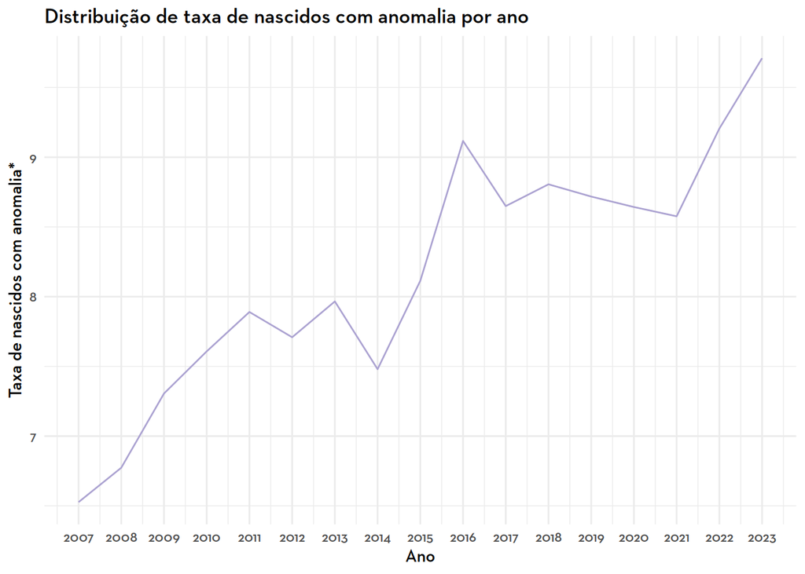

```r
library(ggplot2)
df_sifilis_anomalia |>
  dplyr::filter(ano != "****") |>
  dplyr::mutate(ano = as.numeric(ano)) |>
  ggplot2::ggplot() +
  ggplot2::geom_line(aes(x = ano, y = taxa_anomalia), color = "#ABA2D1") +
  ggplot2::labs(title = "Distribuição de taxa de nascidos com anomalia por ano",
       x = "Ano",
       y = "Taxa de nascidos com anomalia*") +
  ggplot2::theme_minimal() +
  ggplot2::scale_y_continuous(labels = scales::number) +
  ggplot2::scale_x_continuous(breaks = seq(2007, 2023, 1))
```

## Análise bivariada

### Variáveis X por ano

**Mostrar o código**

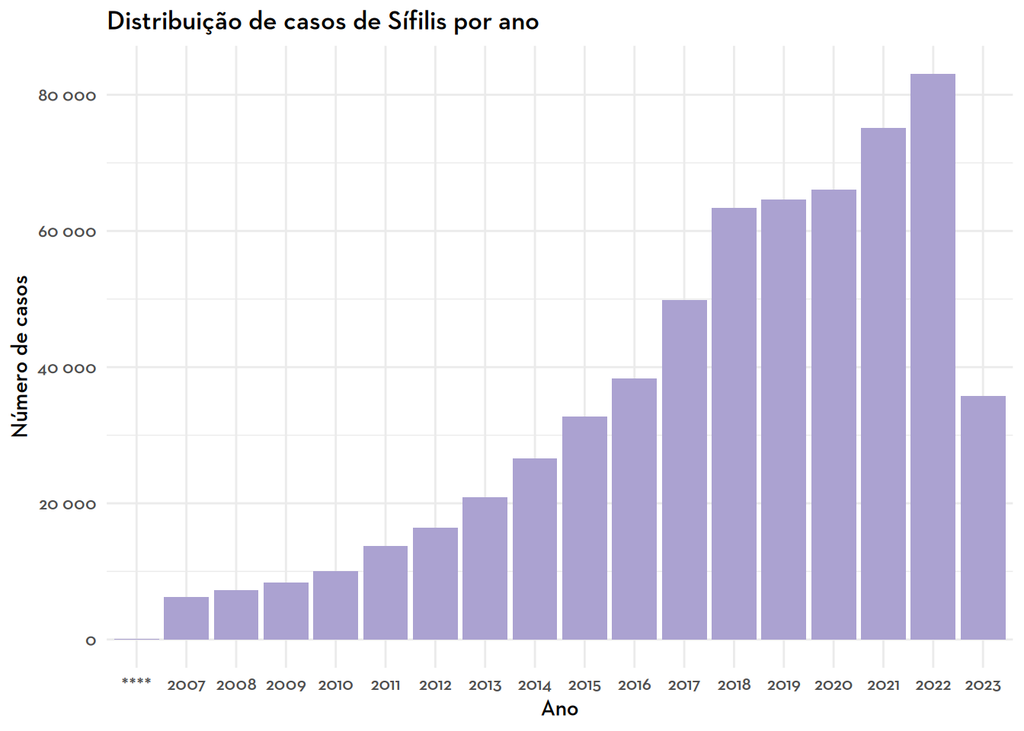

```r
df_sifilis_biv_ano <- df_sifilis |>
  dplyr::group_by(ano) |>
  dplyr::summarise(casos_sifg = sum(casos_sifg)) |>
  dplyr::ungroup()

df_sifilis_biv_ano |>
  ggplot2::ggplot() +
  ggplot2::geom_col(aes(x = ano, y = casos_sifg), fill = "#ABA2D1") +
  ggplot2::labs(title = "Distribuição de casos de Sífilis por ano",
       x = "Ano",
       y = "Número de casos") +
  ggplot2::theme_minimal() +
  ggplot2::scale_y_continuous(labels = scales::number)
```